# Analysis

Charles Marks

January 16, 2019

## The Analysis Plan

o First, a site specific multivariate regression will be developed for each North American site: San Diego, Tijuana, and Vancouver.

o Then, a meta-analysis will be conducted, combining data from each North American site to run the multivariate regression on the combined data.

(Charlie insertion) Use results from step one as predictive model in other states.

## First, Upload the DataSet and Split By Site

```r
df <- read.csv("Jan14_M.csv", header = TRUE)

df <- df[which(!is.na(df$Years_Since_First_Injection)),]
df <- df[which(df$Gender != "Transgender" ),]
df <- df[which(!is.na(df$Ever_Initiated)),]
df <- df[which(!is.na(df$Past_6Mos_Initiated)),]

df$stable_housing <- 0
df$stable_housing[df$Homeless == "No"] <- 1
df$stable_housing <- factor(df$stable_housing, levels = c(0,1), labels = c("No","Yes"))

df$new_initiator <- 0
df$new_initiator[df$Ever_How_Many_Initiates == df$Past_6Mos_How_Many_Initiates & df$Past_6Mos_How_Many_Initiates > 0] <- 1
df$new_initiator <- factor(df$new_initiator, levels = c(0,1), labels = c("No","Yes"))

df$Initiated_Ever_Prior_To_Past_6Mos <- 1
df$Initiated_Ever_Prior_To_Past_6Mos[df$new_initiator == "Yes" | df$Ever_Initiated == "No"] <- 0
df$Initiated_Ever_Prior_To_Past_6Mos <- factor(df$Initiated_Ever_Prior_To_Past_6Mos, levels = c(0,1), labels = c("No","Yes"))

df_ECIV <- df[which(df$SITE == "ECIV"),]
df_STAHR <- df[which(df$SITE == "STAHR"),]
df_VDUS <- df[which(df$SITE == "VDUS"),]
```

## Site-Specific Multivariate Models

### ECIV

#### Bivariate Analyses

```r
ECIV.bi.final <- data.frame(matrix(nrow = 0, ncol = 3))

bi.model <- glm(Past_6Mos_Initiated ~ Initiated_Ever_Prior_To_Past_6Mos, data = df_ECIV, family = binomial(link = "logit"))
bi.results <- exp(cbind(OR = coef(bi.model), confint(bi.model)))
ECIV.bi.final <- rbind(ECIV.bi.final, bi.results)

bi.model <- glm(Past_6Mos_Initiated ~ Age, data = df_ECIV, family = binomial(link = "logit"))
bi.results <- exp(cbind(OR = coef(bi.model), confint(bi.model)))
ECIV.bi.final <- rbind(ECIV.bi.final, bi.results)

bi.model <- glm(Past_6Mos_Initiated ~ Years_Since_First_Injection, data = df_ECIV, family = binomial(link = "logit"))
bi.results <- exp(cbind(OR = coef(bi.model), confint(bi.model)))
ECIV.bi.final <- rbind(ECIV.bi.final, bi.results)

bi.model <- glm(Past_6Mos_Initiated ~ Gender, data = df_ECIV, family = binomial(link = "logit"))
bi.results <- exp(cbind(OR = coef(bi.model), confint(bi.model)))
ECIV.bi.final <- rbind(ECIV.bi.final, bi.results)

bi.model <- glm(Past_6Mos_Initiated ~ stable_housing, data = df_ECIV, family = binomial(link = "logit"))
bi.results <- exp(cbind(OR = coef(bi.model), confint(bi.model)))
ECIV.bi.final <- rbind(ECIV.bi.final, bi.results)

bi.model <- glm(Past_6Mos_Initiated ~ Past_6Mos_Heroin_NonInjection_Use, data = df_ECIV, family = binomial(link = "logit"))
bi.results <- exp(cbind(OR = coef(bi.model), confint(bi.model)))
ECIV.bi.final <- rbind(ECIV.bi.final, bi.results)

bi.model <- glm(Past_6Mos_Initiated ~ Past_6Mos_Heroin_Injection_Use, data = df_ECIV, family = binomial(link = "logit"))
bi.results <- exp(cbind(OR = coef(bi.model), confint(bi.model)))
ECIV.bi.final <- rbind(ECIV.bi.final, bi.results)

bi.model <- glm(Past_6Mos_Initiated ~ Past_6Mos_Cocaine_NonInjection_Use, data = df_ECIV, family = binomial(link = "logit"))
bi.results <- exp(cbind(OR = coef(bi.model), confint(bi.model)))
ECIV.bi.final <- rbind(ECIV.bi.final, bi.results)

bi.model <- glm(Past_6Mos_Initiated ~ Past_6Mos_Cocaine_Injection_Use, data = df_ECIV, family = binomial(link = "logit"))
bi.results <- exp(cbind(OR = coef(bi.model), confint(bi.model)))
ECIV.bi.final <- rbind(ECIV.bi.final, bi.results)

bi.model <- glm(Past_6Mos_Initiated ~ Past_6Mos_Meth_NonInjection_Use, data = df_ECIV, family = binomial(link = "logit"))
bi.results <- exp(cbind(OR = coef(bi.model), confint(bi.model)))
ECIV.bi.final <- rbind(ECIV.bi.final, bi.results)

bi.model <- glm(Past_6Mos_Initiated ~ Past_6Mos_Meth_Injection_Use, data = df_ECIV, family = binomial(link = "logit"))
bi.results <- exp(cbind(OR = coef(bi.model), confint(bi.model)))
ECIV.bi.final <- rbind(ECIV.bi.final, bi.results)

bi.model <- glm(Past_6Mos_Initiated ~ Past_6Mos_Injection_Frequency, data = df_ECIV, family = binomial(link = "logit"))
bi.results <- exp(cbind(OR = coef(bi.model), confint(bi.model)))
ECIV.bi.final <- rbind(ECIV.bi.final, bi.results)

bi.model <- glm(Past_6Mos_Initiated ~ Past_6Mos_MAT, data = df_ECIV, family = binomial(link = "logit"))
bi.results <- exp(cbind(OR = coef(bi.model), confint(bi.model)))
ECIV.bi.final <- rbind(ECIV.bi.final, bi.results)

ECIV.bi.signif <- ECIV.bi.final[which(ECIV.bi.final$`2.5 %` > 1 | ECIV.bi.final$`97.5 %`<1),]

ECIV.bi.final %>%  kable() %>%
  kable_styling()
```

|  | OR | 2.5 % | 97.5 % |
| --- | --- | --- | --- |
| (Intercept) | 0.0285088 | 0.0155824 | 4.736070e-02 |
| Initiated_Ever_Prior_To_Past_6MosYes | 6.6182874 | 2.7049681 | 1.579485e+01 |
| (Intercept)1 | 0.0619511 | 0.0078874 | 4.479748e-01 |
| Age | 0.9922935 | 0.9441876 | 1.040915e+00 |
| (Intercept)2 | 0.0365830 | 0.0127626 | 9.398940e-02 |
| Years_Since_First_Injection | 1.0104442 | 0.9663794 | 1.054595e+00 |
| (Intercept)3 | 0.0199005 | 0.0061349 | 4.683720e-02 |
| GenderMale | 3.0998376 | 1.1453010 | 1.081024e+01 |
| (Intercept)4 | 0.0800000 | 0.0310551 | 1.687935e-01 |
| stable_housingYes | 0.4896313 | 0.1963260 | 1.392991e+00 |
| (Intercept)5 | 0.0448980 | 0.0284238 | 6.706600e-02 |
| Past_6Mos_Heroin_NonInjection_UseYes | 1.1722488 | 0.0638219 | 6.068617e+00 |
| (Intercept)6 | 0.0458015 | 0.0242685 | 7.800050e-02 |
| Past_6Mos_Heroin_Injection_UseYes | 0.9723347 | 0.4147901 | 2.257856e+00 |
| (Intercept)7 | 0.0415842 | 0.0260394 | 6.261900e-02 |
| Past_6Mos_Cocaine_NonInjection_UseYes | 12.0238095 | 1.6035338 | 6.531923e+01 |
| (Intercept)8 | 0.0454545 | 0.0290842 | 6.734470e-02 |
| Past_6Mos_Cocaine_Injection_UseYes | 0.0000038 | NA | 1.436981e+42 |
| (Intercept)9 | 0.0400000 | 0.0223393 | 6.555640e-02 |
| Past_6Mos_Meth_NonInjection_UseYes | 1.4150943 | 0.5785482 | 3.295114e+00 |
| (Intercept)10 | 0.0375276 | 0.0222276 | 5.889970e-02 |
| Past_6Mos_Meth_Injection_UseYes | 2.8550420 | 0.9964094 | 7.192528e+00 |
| (Intercept)11 | 0.0494792 | 0.0301472 | 7.613930e-02 |
| Past_6Mos_Injection_FrequencyLess than daily | 0.5614035 | 0.0308037 | 2.830810e+00 |
| Past_6Mos_Injection_FrequencyNone | 0.6812537 | 0.1576413 | 2.054043e+00 |
| (Intercept)12 | 0.0440882 | 0.0279151 | 6.584390e-02 |
| Past_6Mos_MATYes | 2.2681818 | 0.1209476 | 1.265505e+01 |

## MV

First we just want to build MV model for never and ever

```r
ECIV.model.null = glm(Past_6Mos_Initiated ~ 1,
                 data=df_ECIV,
                 family = binomial(link="logit")
                 )

ECIV.model.full = glm(Past_6Mos_Initiated ~ Age + Gender + Years_Since_First_Injection + stable_housing +Past_6Mos_Heroin_NonInjection_Use + Past_6Mos_Heroin_Injection_Use + Past_6Mos_Cocaine_NonInjection_Use + Past_6Mos_Cocaine_Injection_Use + + Past_6Mos_Meth_NonInjection_Use + Past_6Mos_Meth_Injection_Use + Past_6Mos_Injection_Frequency + Past_6Mos_MAT + Initiated_Ever_Prior_To_Past_6Mos,
                 data=df_ECIV,
                 family = binomial(link="logit")
                 )

ECIV.step.results <- step(ECIV.model.null,
     scope = list(upper=ECIV.model.full),
             direction="both",
             test="Chisq",
             data=df_ECIV, trace = 0)

ECIV.final.model <- eval(ECIV.step.results$call)

ECIV.results <- round(exp(cbind(OR = coef(ECIV.final.model), confint(ECIV.final.model))),2)
print("The Results of the Stepwise Model")
```

```
## [1] "The Results of the Stepwise Model"
```

```r
ECIV.results %>%  kable() %>%
  kable_styling()
```

|  | OR | 2.5 % | 97.5 % |
| --- | --- | --- | --- |
| (Intercept) | 0.01 | 0.00 | 0.03 |
| Initiated_Ever_Prior_To_Past_6MosYes | 5.06 | 1.96 | 12.56 |
| GenderMale | 2.53 | 0.91 | 8.98 |
| Past_6Mos_Meth_Injection_UseYes | 2.57 | 0.84 | 6.90 |
| Past_6Mos_Cocaine_NonInjection_UseYes | 6.02 | 0.63 | 45.36 |

```r
ECIV.full.results <- round(exp(cbind(OR = coef(ECIV.model.full), confint(ECIV.model.full))),2)
print("The Results of the Full Model")
```

```
## [1] "The Results of the Full Model"
```

```r
ECIV.full.results  %>%  kable() %>%
  kable_styling()
```

|  | OR | 2.5 % | 97.5 % |
| --- | --- | --- | --- |
| (Intercept) | 0.04 | 0.00 | 5.900000e-01 |
| Age | 0.96 | 0.88 | 1.040000e+00 |
| GenderMale | 3.06 | 1.02 | 1.142000e+01 |
| Years_Since_First_Injection | 1.02 | 0.95 | 1.110000e+00 |
| stable_housingYes | 0.75 | 0.26 | 2.580000e+00 |
| Past_6Mos_Heroin_NonInjection_UseYes | 0.58 | 0.02 | 4.850000e+00 |
| Past_6Mos_Heroin_Injection_UseYes | 0.77 | 0.28 | 2.120000e+00 |
| Past_6Mos_Cocaine_NonInjection_UseYes | 5.89 | 0.48 | 6.561000e+01 |
| Past_6Mos_Cocaine_Injection_UseYes | 0.00 | NA | 8.550771e+58 |
| Past_6Mos_Meth_NonInjection_UseYes | 1.84 | 0.68 | 4.800000e+00 |
| Past_6Mos_Meth_Injection_UseYes | 2.95 | 0.85 | 9.110000e+00 |
| Past_6Mos_Injection_FrequencyLess than daily | 0.50 | 0.03 | 2.770000e+00 |
| Past_6Mos_Injection_FrequencyNone | 0.71 | 0.14 | 2.780000e+00 |
| Past_6Mos_MATYes | 6.73 | 0.33 | 4.683000e+01 |
| Initiated_Ever_Prior_To_Past_6MosYes | 5.71 | 2.14 | 1.476000e+01 |

### STAHR

#### Bivariate Analyses

```r
STAHR.bi.final <- data.frame(matrix(nrow = 0, ncol = 3))

bi.model <- glm(Past_6Mos_Initiated ~ Initiated_Ever_Prior_To_Past_6Mos, data = df_STAHR, family = binomial(link = "logit"))
bi.results <- exp(cbind(OR = coef(bi.model), confint(bi.model)))
STAHR.bi.final <- rbind(STAHR.bi.final, bi.results)

bi.model <- glm(Past_6Mos_Initiated ~ Age, data = df_STAHR, family = binomial(link = "logit"))
bi.results <- exp(cbind(OR = coef(bi.model), confint(bi.model)))
STAHR.bi.final <- rbind(STAHR.bi.final, bi.results)

bi.model <- glm(Past_6Mos_Initiated ~ Years_Since_First_Injection, data = df_STAHR, family = binomial(link = "logit"))
bi.results <- exp(cbind(OR = coef(bi.model), confint(bi.model)))
STAHR.bi.final <- rbind(STAHR.bi.final, bi.results)

bi.model <- glm(Past_6Mos_Initiated ~ Gender, data = df_STAHR, family = binomial(link = "logit"))
bi.results <- exp(cbind(OR = coef(bi.model), confint(bi.model)))
STAHR.bi.final <- rbind(STAHR.bi.final, bi.results)

bi.model <- glm(Past_6Mos_Initiated ~ stable_housing, data = df_STAHR, family = binomial(link = "logit"))
bi.results <- exp(cbind(OR = coef(bi.model), confint(bi.model)))
STAHR.bi.final <- rbind(STAHR.bi.final, bi.results)

bi.model <- glm(Past_6Mos_Initiated ~ Past_6Mos_Heroin_NonInjection_Use, data = df_STAHR, family = binomial(link = "logit"))
bi.results <- exp(cbind(OR = coef(bi.model), confint(bi.model)))
STAHR.bi.final <- rbind(STAHR.bi.final, bi.results)

bi.model <- glm(Past_6Mos_Initiated ~ Past_6Mos_Heroin_Injection_Use, data = df_STAHR, family = binomial(link = "logit"))
bi.results <- exp(cbind(OR = coef(bi.model), confint(bi.model)))
STAHR.bi.final <- rbind(STAHR.bi.final, bi.results)

bi.model <- glm(Past_6Mos_Initiated ~ Past_6Mos_Cocaine_NonInjection_Use, data = df_STAHR, family = binomial(link = "logit"))
bi.results <- exp(cbind(OR = coef(bi.model), confint(bi.model)))
STAHR.bi.final <- rbind(STAHR.bi.final, bi.results)

bi.model <- glm(Past_6Mos_Initiated ~ Past_6Mos_Cocaine_Injection_Use, data = df_STAHR, family = binomial(link = "logit"))
bi.results <- exp(cbind(OR = coef(bi.model), confint(bi.model)))
STAHR.bi.final <- rbind(STAHR.bi.final, bi.results)

bi.model <- glm(Past_6Mos_Initiated ~ Past_6Mos_Meth_NonInjection_Use, data = df_STAHR, family = binomial(link = "logit"))
bi.results <- exp(cbind(OR = coef(bi.model), confint(bi.model)))
STAHR.bi.final <- rbind(STAHR.bi.final, bi.results)

bi.model <- glm(Past_6Mos_Initiated ~ Past_6Mos_Meth_Injection_Use, data = df_STAHR, family = binomial(link = "logit"))
bi.results <- exp(cbind(OR = coef(bi.model), confint(bi.model)))
STAHR.bi.final <- rbind(STAHR.bi.final, bi.results)

bi.model <- glm(Past_6Mos_Initiated ~ Past_6Mos_Injection_Frequency, data = df_STAHR, family = binomial(link = "logit"))
bi.results <- exp(cbind(OR = coef(bi.model), confint(bi.model)))
STAHR.bi.final <- rbind(STAHR.bi.final, bi.results)

bi.model <- glm(Past_6Mos_Initiated ~ Past_6Mos_MAT, data = df_STAHR, family = binomial(link = "logit"))
bi.results <- exp(cbind(OR = coef(bi.model), confint(bi.model)))
STAHR.bi.final <- rbind(STAHR.bi.final, bi.results)



STAHR.bi.signif <- STAHR.bi.final[which(STAHR.bi.final$`2.5 %` > 1 | STAHR.bi.final$`97.5 %`<1),]

STAHR.bi.final %>%  kable() %>%
  kable_styling()
```

|  | OR | 2.5 % | 97.5 % |
| --- | --- | --- | --- |
| (Intercept) | 0.0322581 | 0.0137346 | 0.0633199 |
| Initiated_Ever_Prior_To_Past_6MosYes | 3.0720721 | 1.1771332 | 8.5541194 |
| (Intercept)1 | 0.0606384 | 0.0070134 | 0.4050914 |
| Age | 0.9978647 | 0.9572064 | 1.0417589 |
| (Intercept)2 | 0.0623547 | 0.0219272 | 0.1534753 |
| Years_Since_First_Injection | 0.9945720 | 0.9579223 | 1.0311443 |
| (Intercept)3 | 0.0425532 | 0.0130180 | 0.1016578 |
| GenderMale | 1.4059827 | 0.4897181 | 5.0580063 |
| (Intercept)4 | 0.0615385 | 0.0276631 | 0.1175802 |
| stable_housingYes | 0.8207071 | 0.3155340 | 2.2016780 |
| (Intercept)5 | 0.0632411 | 0.0366188 | 0.1012751 |
| Past_6Mos_Heroin_NonInjection_UseYes | 0.4216667 | 0.0657244 | 1.5267502 |
| (Intercept)6 | 0.0625000 | 0.0329919 | 0.1070299 |
| Past_6Mos_Heroin_Injection_UseYes | 0.7058824 | 0.2407045 | 1.8648796 |
| (Intercept)7 | 0.0535714 | 0.0304827 | 0.0867879 |
| Past_6Mos_Cocaine_NonInjection_UseYes | 1.1666667 | 0.2631748 | 3.7020075 |
| (Intercept)8 | 0.0544872 | 0.0321655 | 0.0859131 |
| Past_6Mos_Cocaine_Injection_UseYes | 1.1470588 | 0.0617720 | 6.1645539 |
| (Intercept)9 | 0.0396825 | 0.0140505 | 0.0872365 |
| Past_6Mos_Meth_NonInjection_UseYes | 1.6217822 | 0.5959212 | 5.1538809 |
| (Intercept)10 | 0.0329670 | 0.0129735 | 0.0679296 |
| Past_6Mos_Meth_Injection_UseYes | 2.4931507 | 0.9442158 | 7.3092990 |
| (Intercept)11 | 0.0873786 | 0.0410641 | 0.1630353 |
| Past_6Mos_Injection_FrequencyLess than daily | 0.7504554 | 0.2725718 | 2.0311032 |
| Past_6Mos_Injection_FrequencyNone | 0.1111111 | 0.0059712 | 0.6068189 |
| (Intercept)12 | 0.0651341 | 0.0383710 | 0.1029970 |
| Past_6Mos_MATYes | 0.2291485 | 0.0126053 | 1.1467157 |

#### Multivariate Log Reg

```r
STAHR.model.null = glm(Past_6Mos_Initiated ~ 1,
                 data=df_STAHR,
                 family = binomial(link="logit")
                 )

STAHR.model.full = glm(Past_6Mos_Initiated ~ Age + Gender + stable_housing + Years_Since_First_Injection +Past_6Mos_Heroin_NonInjection_Use + Past_6Mos_Heroin_Injection_Use + Past_6Mos_Cocaine_NonInjection_Use + Past_6Mos_Cocaine_Injection_Use + + Past_6Mos_Meth_NonInjection_Use + Past_6Mos_Meth_Injection_Use + Past_6Mos_Injection_Frequency + Past_6Mos_MAT + Initiated_Ever_Prior_To_Past_6Mos,
                 data=df_STAHR,
                 family = binomial(link="logit")
                 )

STAHR.step.results <- step(STAHR.model.null,
     scope = list(upper=STAHR.model.full),
             direction="both",
             test="Chisq",
             data=df_STAHR, trace = 0)

STAHR.final.model <- eval(STAHR.step.results$call)


STAHR.results <- round(exp(cbind(OR = coef(STAHR.final.model), confint(STAHR.final.model))),2)
print("The Results of the Stepwise Model")
```

```
## [1] "The Results of the Stepwise Model"
```

```r
STAHR.results %>%  kable() %>%
  kable_styling()
```

|  | OR | 2.5 % | 97.5 % |
| --- | --- | --- | --- |
| (Intercept) | 0.09 | 0.03 | 0.21 |
| Past_6Mos_Injection_FrequencyLess than daily | 0.64 | 0.23 | 1.78 |
| Past_6Mos_Injection_FrequencyNone | 0.08 | 0.00 | 0.45 |
| Initiated_Ever_Prior_To_Past_6MosYes | 3.05 | 1.14 | 8.67 |
| Past_6Mos_Heroin_NonInjection_UseYes | 0.28 | 0.04 | 1.07 |
| Past_6Mos_MATYes | 0.25 | 0.01 | 1.31 |

```r
STAHR.full.results <- round(exp(cbind(OR = coef(STAHR.model.full), confint(STAHR.model.full))),2)
print("The Results of the Full Model")
```

```
## [1] "The Results of the Full Model"
```

```r
STAHR.full.results %>%  kable() %>%
  kable_styling()
```

|  | OR | 2.5 % | 97.5 % |
| --- | --- | --- | --- |
| (Intercept) | 0.32 | 0.01 | 12.48 |
| Age | 1.00 | 0.93 | 1.07 |
| GenderMale | 1.44 | 0.45 | 5.71 |
| stable_housingYes | 0.87 | 0.31 | 2.54 |
| Years_Since_First_Injection | 0.99 | 0.93 | 1.05 |
| Past_6Mos_Heroin_NonInjection_UseYes | 0.33 | 0.04 | 1.53 |
| Past_6Mos_Heroin_Injection_UseYes | 0.28 | 0.03 | 1.66 |
| Past_6Mos_Cocaine_NonInjection_UseYes | 1.60 | 0.29 | 6.78 |
| Past_6Mos_Cocaine_Injection_UseYes | 0.93 | 0.04 | 7.68 |
| Past_6Mos_Meth_NonInjection_UseYes | 0.91 | 0.25 | 3.66 |
| Past_6Mos_Meth_Injection_UseYes | 0.28 | 0.02 | 1.91 |
| Past_6Mos_Injection_FrequencyLess than daily | 0.63 | 0.21 | 1.84 |
| Past_6Mos_Injection_FrequencyNone | 0.02 | 0.00 | 0.27 |
| Past_6Mos_MATYes | 0.29 | 0.01 | 2.00 |
| Initiated_Ever_Prior_To_Past_6MosYes | 3.05 | 1.08 | 9.29 |

### VDUS

#### Bivariate Analyses

```r
VDUS.bi.final <- data.frame(matrix(nrow = 0, ncol = 3))

bi.model <- glm(Past_6Mos_Initiated ~ Initiated_Ever_Prior_To_Past_6Mos, data = df_VDUS, family = binomial(link = "logit"))
bi.results <- exp(cbind(OR = coef(bi.model), confint(bi.model)))
VDUS.bi.final <- rbind(VDUS.bi.final, bi.results)

bi.model <- glm(Past_6Mos_Initiated ~ Age, data = df_VDUS, family = binomial(link = "logit"))
bi.results <- exp(cbind(OR = coef(bi.model), confint(bi.model)))
VDUS.bi.final <- rbind(VDUS.bi.final, bi.results)

bi.model <- glm(Past_6Mos_Initiated ~ Years_Since_First_Injection, data = df_VDUS, family = binomial(link = "logit"))
bi.results <- exp(cbind(OR = coef(bi.model), confint(bi.model)))
VDUS.bi.final <- rbind(VDUS.bi.final, bi.results)

bi.model <- glm(Past_6Mos_Initiated ~ Gender, data = df_VDUS, family = binomial(link = "logit"))
bi.results <- exp(cbind(OR = coef(bi.model), confint(bi.model)))
VDUS.bi.final <- rbind(VDUS.bi.final, bi.results)

bi.model <- glm(Past_6Mos_Initiated ~ stable_housing, data = df_VDUS, family = binomial(link = "logit"))
bi.results <- exp(cbind(OR = coef(bi.model), confint(bi.model)))
VDUS.bi.final <- rbind(VDUS.bi.final, bi.results)

bi.model <- glm(Past_6Mos_Initiated ~ Past_6Mos_Heroin_NonInjection_Use, data = df_VDUS, family = binomial(link = "logit"))
bi.results <- exp(cbind(OR = coef(bi.model), confint(bi.model)))
VDUS.bi.final <- rbind(VDUS.bi.final, bi.results)

bi.model <- glm(Past_6Mos_Initiated ~ Past_6Mos_Heroin_Injection_Use, data = df_VDUS, family = binomial(link = "logit"))
bi.results <- exp(cbind(OR = coef(bi.model), confint(bi.model)))
VDUS.bi.final <- rbind(VDUS.bi.final, bi.results)

bi.model <- glm(Past_6Mos_Initiated ~ Past_6Mos_Cocaine_NonInjection_Use, data = df_VDUS, family = binomial(link = "logit"))
bi.results <- exp(cbind(OR = coef(bi.model), confint(bi.model)))
VDUS.bi.final <- rbind(VDUS.bi.final, bi.results)

bi.model <- glm(Past_6Mos_Initiated ~ Past_6Mos_Cocaine_Injection_Use, data = df_VDUS, family = binomial(link = "logit"))
bi.results <- exp(cbind(OR = coef(bi.model), confint(bi.model)))
VDUS.bi.final <- rbind(VDUS.bi.final, bi.results)

bi.model <- glm(Past_6Mos_Initiated ~ Past_6Mos_Meth_NonInjection_Use, data = df_VDUS, family = binomial(link = "logit"))
bi.results <- exp(cbind(OR = coef(bi.model), confint(bi.model)))
VDUS.bi.final <- rbind(VDUS.bi.final, bi.results)

bi.model <- glm(Past_6Mos_Initiated ~ Past_6Mos_Meth_Injection_Use, data = df_VDUS, family = binomial(link = "logit"))
bi.results <- exp(cbind(OR = coef(bi.model), confint(bi.model)))
VDUS.bi.final <- rbind(VDUS.bi.final, bi.results)

bi.model <- glm(Past_6Mos_Initiated ~ Past_6Mos_Injection_Frequency, data = df_VDUS, family = binomial(link = "logit"))
bi.results <- exp(cbind(OR = coef(bi.model), confint(bi.model)))
VDUS.bi.final <- rbind(VDUS.bi.final, bi.results)

bi.model <- glm(Past_6Mos_Initiated ~ Past_6Mos_MAT, data = df_VDUS, family = binomial(link = "logit"))
bi.results <- exp(cbind(OR = coef(bi.model), confint(bi.model)))
VDUS.bi.final <- rbind(VDUS.bi.final, bi.results)



VDUS.bi.signif <- VDUS.bi.final[which(VDUS.bi.final$`2.5 %` > 1 | VDUS.bi.final$`97.5 %`<1),]
VDUS.bi.final %>%  kable() %>%
  kable_styling()
```

|  | OR | 2.5 % | 97.5 % |
| --- | --- | --- | --- |
| (Intercept) | 0.0103481 | 0.0053597 | 0.0177863 |
| Initiated_Ever_Prior_To_Past_6MosYes | 13.8051948 | 7.1385001 | 28.8572311 |
| (Intercept)1 | 0.5009414 | 0.1886200 | 1.3046021 |
| Age | 0.9354244 | 0.9105995 | 0.9592982 |
| (Intercept)2 | 0.0841581 | 0.0509882 | 0.1332885 |
| Years_Since_First_Injection | 0.9540410 | 0.9295420 | 0.9773475 |
| (Intercept)3 | 0.0335570 | 0.0191736 | 0.0540463 |
| GenderMale | 1.0729384 | 0.5827837 | 2.0621787 |
| (Intercept)4 | 0.0792683 | 0.0428493 | 0.1338208 |
| stable_housingYes | 0.3639053 | 0.1919428 | 0.7299237 |
| (Intercept)5 | 0.0319934 | 0.0228716 | 0.0433498 |
| Past_6Mos_Heroin_NonInjection_UseYes | 2.4583693 | 0.9834217 | 5.3325073 |
| (Intercept)6 | 0.0160920 | 0.0090334 | 0.0261808 |
| Past_6Mos_Heroin_Injection_UseYes | 4.5401174 | 2.4459956 | 8.8625282 |
| (Intercept)7 | 0.0320135 | 0.0227803 | 0.0435414 |
| Past_6Mos_Cocaine_NonInjection_UseYes | 2.0652458 | 0.8776578 | 4.3071435 |
| (Intercept)8 | 0.0313943 | 0.0218869 | 0.0434136 |
| Past_6Mos_Cocaine_Injection_UseYes | 1.6988235 | 0.8326888 | 3.2427588 |
| (Intercept)9 | 0.0298939 | 0.0204723 | 0.0419311 |
| Past_6Mos_Meth_NonInjection_UseYes | 1.8515653 | 0.9600226 | 3.4227752 |
| (Intercept)10 | 0.0129611 | 0.0071089 | 0.0214248 |
| Past_6Mos_Meth_Injection_UseYes | 8.3477932 | 4.4414948 | 16.6297839 |
| (Intercept)11 | 0.0937500 | 0.0643932 | 0.1317600 |
| Past_6Mos_Injection_FrequencyLess than daily | 0.3004695 | 0.1385730 | 0.5973589 |
| Past_6Mos_Injection_FrequencyNone | 0.0532446 | 0.0127420 | 0.1497449 |
| (Intercept)12 | 0.0421512 | 0.0284206 | 0.0599168 |
| Past_6Mos_MATYes | 0.6505006 | 0.3471084 | 1.1824550 |

#### Multivariate Log Reg

```r
VDUS.model.null = glm(Past_6Mos_Initiated ~ 1,
                 data=df_VDUS,
                 family = binomial(link="logit")
                 )

VDUS.model.full = glm(Past_6Mos_Initiated ~ Age + Gender + stable_housing + Years_Since_First_Injection +Past_6Mos_Heroin_NonInjection_Use + Past_6Mos_Heroin_Injection_Use + Past_6Mos_Cocaine_NonInjection_Use + Past_6Mos_Cocaine_Injection_Use + + Past_6Mos_Meth_NonInjection_Use + Past_6Mos_Meth_Injection_Use + Past_6Mos_Injection_Frequency + Past_6Mos_MAT + Initiated_Ever_Prior_To_Past_6Mos,
                 data=df_VDUS,
                 family = binomial(link="logit")
                 )

VDUS.step.results <- step(VDUS.model.null,
     scope = list(upper=VDUS.model.full),
             direction="both",
             test="Chisq",
             data=df_VDUS, trace = 0)

VDUS.final.model <- eval(VDUS.step.results$call)


VDUS.results <- round(exp(cbind(OR = coef(VDUS.final.model), confint(VDUS.final.model))),2)
print("The Results of the Stepwise Model")
```

```
## [1] "The Results of the Stepwise Model"
```

```r
VDUS.results %>%  kable() %>%
  kable_styling()
```

|  | OR | 2.5 % | 97.5 % |
| --- | --- | --- | --- |
| (Intercept) | 0.12 | 0.02 | 0.51 |
| Initiated_Ever_Prior_To_Past_6MosYes | 13.20 | 6.49 | 29.04 |
| Past_6Mos_Meth_Injection_UseYes | 3.16 | 1.40 | 7.60 |
| Age | 0.95 | 0.92 | 0.98 |
| Past_6Mos_Injection_FrequencyLess than daily | 0.39 | 0.17 | 0.86 |
| Past_6Mos_Injection_FrequencyNone | 0.13 | 0.03 | 0.46 |
| Past_6Mos_Cocaine_NonInjection_UseYes | 2.88 | 1.03 | 7.42 |
| Past_6Mos_MATYes | 0.53 | 0.26 | 1.05 |
| Past_6Mos_Meth_NonInjection_UseYes | 0.50 | 0.22 | 1.09 |

```r
VDUS.full.results <- round(exp(cbind(OR = coef(VDUS.model.full), confint(VDUS.model.full))),2)
print("The Results of the Full Model")
```

```
## [1] "The Results of the Full Model"
```

```r
VDUS.full.results %>%  kable() %>%
  kable_styling()
```

|  | OR | 2.5 % | 97.5 % |
| --- | --- | --- | --- |
| (Intercept) | 0.08 | 0.01 | 0.58 |
| Age | 0.96 | 0.90 | 1.01 |
| GenderMale | 1.26 | 0.60 | 2.71 |
| stable_housingYes | 0.88 | 0.39 | 2.07 |
| Years_Since_First_Injection | 1.00 | 0.95 | 1.05 |
| Past_6Mos_Heroin_NonInjection_UseYes | 1.36 | 0.40 | 4.08 |
| Past_6Mos_Heroin_Injection_UseYes | 1.33 | 0.55 | 3.35 |
| Past_6Mos_Cocaine_NonInjection_UseYes | 2.56 | 0.85 | 7.13 |
| Past_6Mos_Cocaine_Injection_UseYes | 0.90 | 0.37 | 2.09 |
| Past_6Mos_Meth_NonInjection_UseYes | 0.46 | 0.19 | 1.06 |
| Past_6Mos_Meth_Injection_UseYes | 3.12 | 1.35 | 7.64 |
| Past_6Mos_Injection_FrequencyLess than daily | 0.42 | 0.17 | 0.98 |
| Past_6Mos_Injection_FrequencyNone | 0.16 | 0.03 | 0.74 |
| Past_6Mos_MATYes | 0.51 | 0.24 | 1.06 |
| Initiated_Ever_Prior_To_Past_6MosYes | 13.49 | 6.54 | 30.03 |

### Prediction

So, we will use the models as a predictive model on the other sites to see if the results from one site are an “effective” tool for understanding initiation in other sites. There will be six total predictions run, corresponding to the three sites predicting the other two sites each.

#### ECIV as predictor

So we will take our two final ECIV models, ECIV.final.model and ECIV.model.full to predict the outcome in STAHR and VDUS

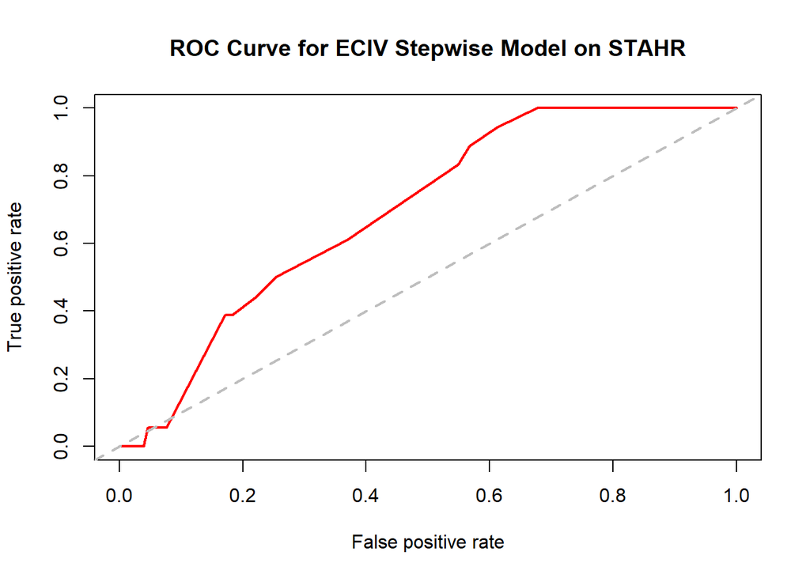

```r
ECIV.STAHR.pr <- predict(ECIV.final.model, df_STAHR, type="response")
ECIV.STAHR.pred <- prediction(ECIV.STAHR.pr, df_STAHR$Past_6Mos_Initiated)
ECIV.STAHR.perf <- performance(ECIV.STAHR.pred,measure = "tpr",x.measure = "fpr")
plot(ECIV.STAHR.perf,main="ROC Curve for ECIV Stepwise Model on STAHR",col=2,lwd=2)
abline(a=0,b=1,lwd=2,lty=2,col="gray")
```

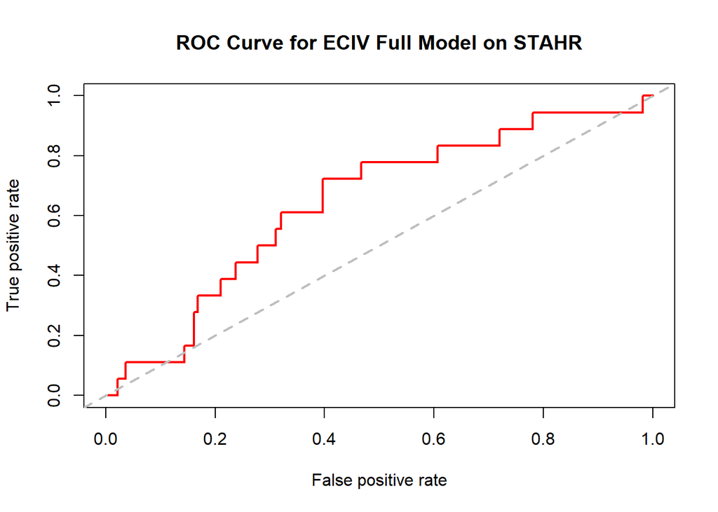

```r
ECIV.STAHR.full.pr <- predict(ECIV.model.full, df_STAHR, type="response")
ECIV.STAHR.full.pred <- prediction(ECIV.STAHR.full.pr, df_STAHR$Past_6Mos_Initiated)
ECIV.STAHR.full.perf <- performance(ECIV.STAHR.full.pred,measure = "tpr",x.measure = "fpr")
plot(ECIV.STAHR.full.perf,main="ROC Curve for ECIV Full Model on STAHR",col=2,lwd=2)
abline(a=0,b=1,lwd=2,lty=2,col="gray")
```

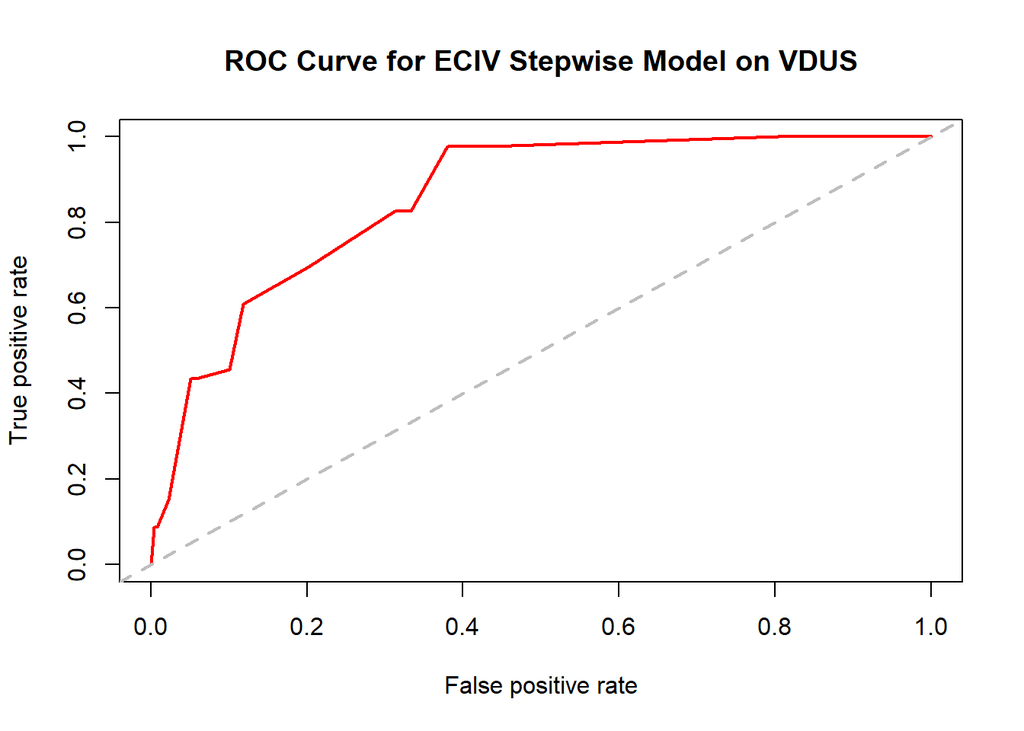

```r
ECIV.VDUS.pr <- predict(ECIV.final.model, df_VDUS, type="response")
ECIV.VDUS.pred <- prediction(ECIV.VDUS.pr, df_VDUS$Past_6Mos_Initiated)
ECIV.VDUS.perf <- performance(ECIV.VDUS.pred,measure = "tpr",x.measure = "fpr")
plot(ECIV.VDUS.perf,main="ROC Curve for ECIV Stepwise Model on VDUS",col=2,lwd=2)
abline(a=0,b=1,lwd=2,lty=2,col="gray")
```

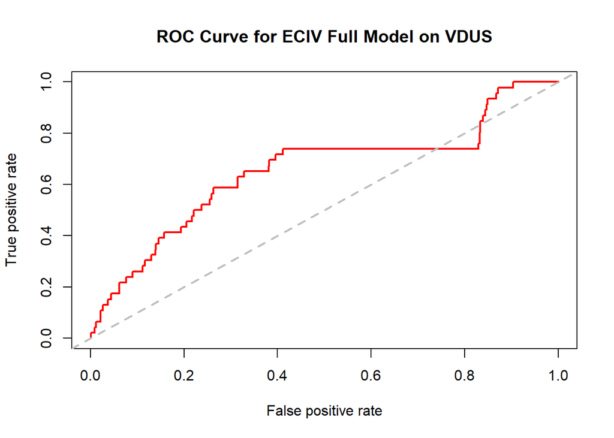

```r
ECIV.VDUS.full.pr <- predict(ECIV.model.full, df_VDUS, type="response")
ECIV.VDUS.full.pred <- prediction(ECIV.VDUS.full.pr, df_VDUS$Past_6Mos_Initiated)
ECIV.VDUS.full.perf <- performance(ECIV.VDUS.full.pred,measure = "tpr",x.measure = "fpr")
plot(ECIV.VDUS.full.perf,main="ROC Curve for ECIV Full Model on VDUS",col=2,lwd=2)
abline(a=0,b=1,lwd=2,lty=2,col="gray")
```

#### STAHR as predictor

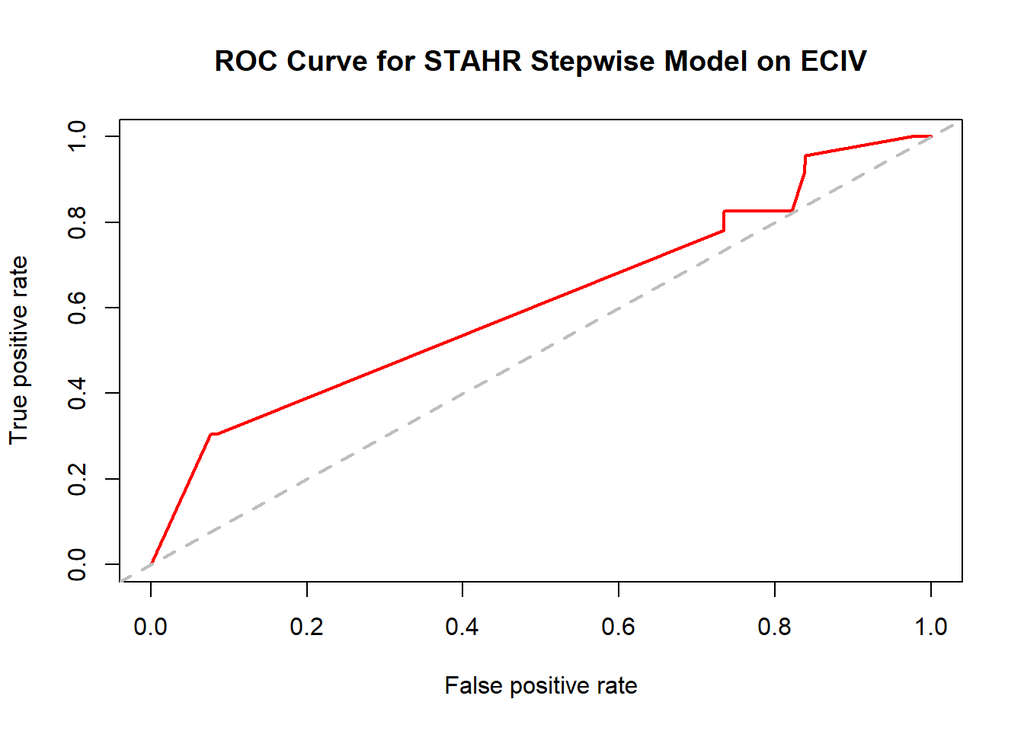

```r
STAHR.ECIV.pr <- predict(STAHR.final.model, df_ECIV, type="response")
STAHR.ECIV.pred <- prediction(STAHR.ECIV.pr, df_ECIV$Past_6Mos_Initiated)
STAHR.ECIV.perf <- performance(STAHR.ECIV.pred,measure = "tpr",x.measure = "fpr")
plot(STAHR.ECIV.perf,main="ROC Curve for STAHR Stepwise Model on ECIV",col=2,lwd=2)
abline(a=0,b=1,lwd=2,lty=2,col="gray")
```

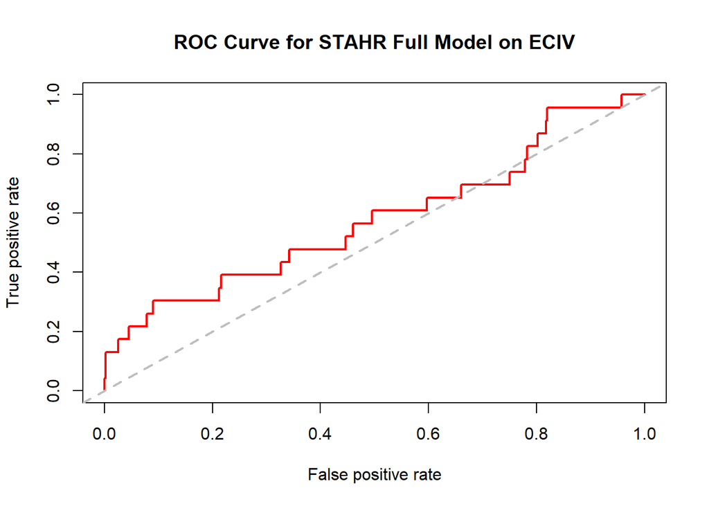

```r
STAHR.ECIV.full.pr <- predict(STAHR.model.full, df_ECIV, type="response")
STAHR.ECIV.full.pred <- prediction(STAHR.ECIV.full.pr, df_ECIV$Past_6Mos_Initiated)
STAHR.ECIV.full.perf <- performance(STAHR.ECIV.full.pred,measure = "tpr",x.measure = "fpr")
plot(STAHR.ECIV.full.perf,main="ROC Curve for STAHR Full Model on ECIV",col=2,lwd=2)
abline(a=0,b=1,lwd=2,lty=2,col="gray")
```

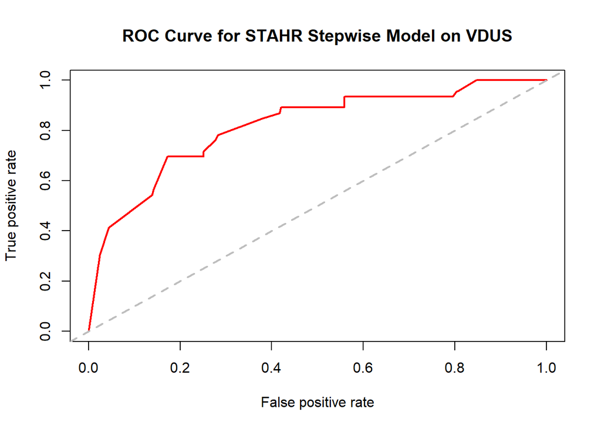

```r
STAHR.VDUS.pr <- predict(STAHR.final.model, df_VDUS, type="response")
STAHR.VDUS.pred <- prediction(STAHR.VDUS.pr, df_VDUS$Past_6Mos_Initiated)
STAHR.VDUS.perf <- performance(STAHR.VDUS.pred,measure = "tpr",x.measure = "fpr")
plot(STAHR.VDUS.perf,main="ROC Curve for STAHR Stepwise Model on VDUS",col=2,lwd=2)
abline(a=0,b=1,lwd=2,lty=2,col="gray")
```

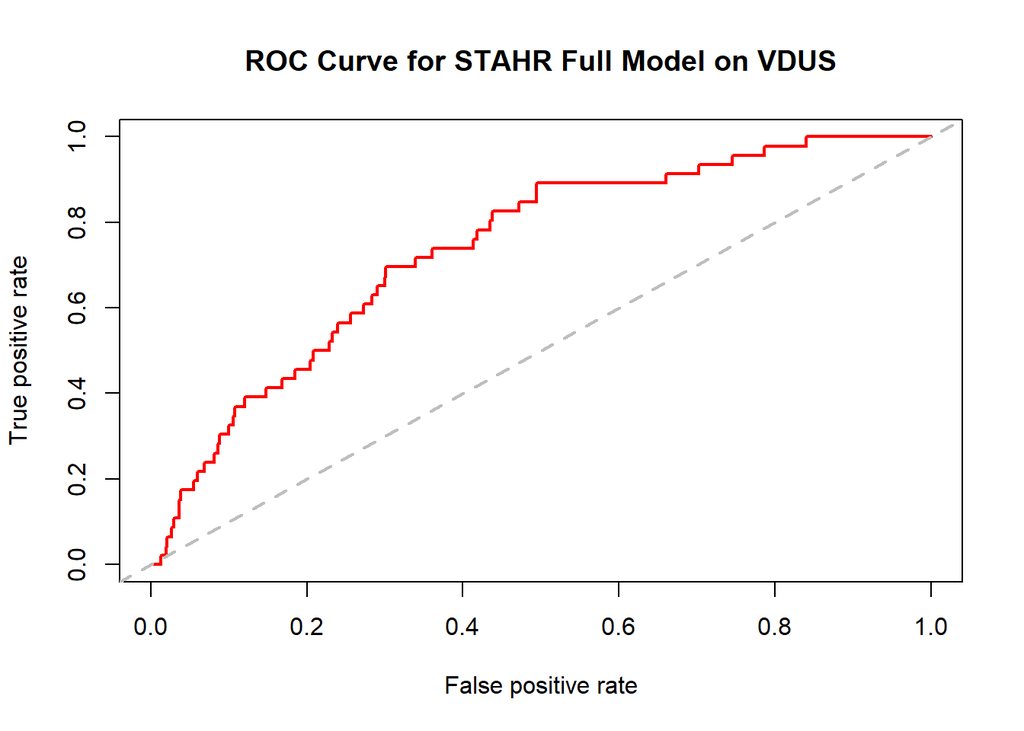

```r
STAHR.VDUS.full.pr <- predict(STAHR.model.full, df_VDUS, type="response")
STAHR.VDUS.full.pred <- prediction(STAHR.VDUS.full.pr, df_VDUS$Past_6Mos_Initiated)
STAHR.VDUS.full.perf <- performance(STAHR.VDUS.full.pred,measure = "tpr",x.measure = "fpr")
plot(STAHR.VDUS.full.perf,main="ROC Curve for STAHR Full Model on VDUS",col=2,lwd=2)
abline(a=0,b=1,lwd=2,lty=2,col="gray")
```

#### VDUS as predictor

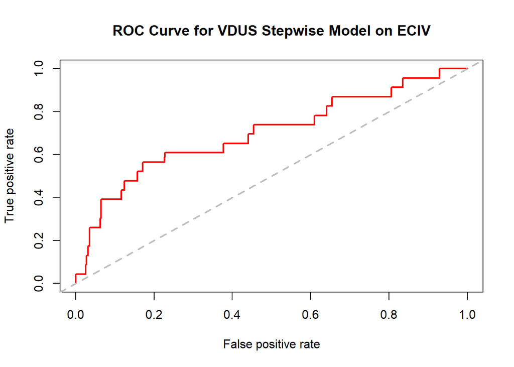

```r
VDUS.ECIV.pr <- predict(VDUS.final.model, df_ECIV, type="response")
VDUS.ECIV.pred <- prediction(VDUS.ECIV.pr, df_ECIV$Past_6Mos_Initiated)
VDUS.ECIV.perf <- performance(VDUS.ECIV.pred,measure = "tpr",x.measure = "fpr")
plot(VDUS.ECIV.perf,main="ROC Curve for VDUS Stepwise Model on ECIV",col=2,lwd=2)
abline(a=0,b=1,lwd=2,lty=2,col="gray")
```

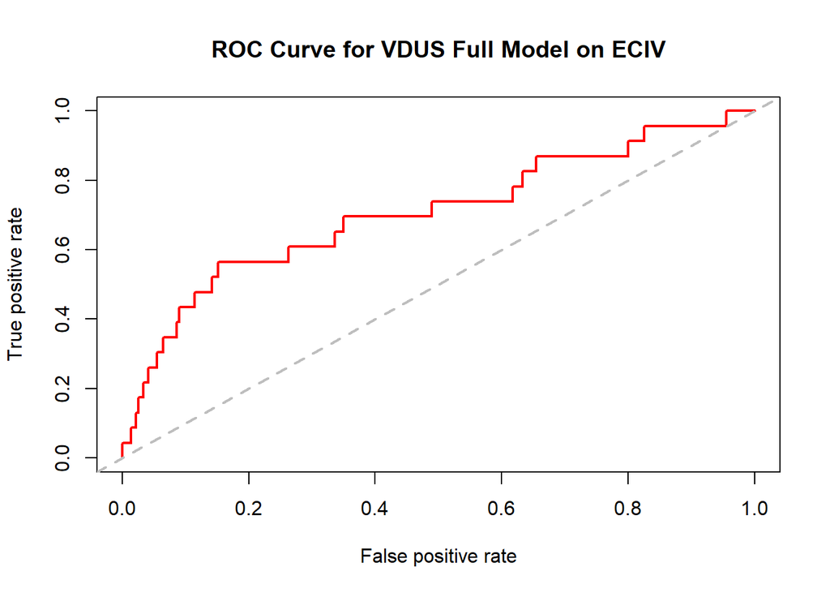

```r
VDUS.ECIV.full.pr <- predict(VDUS.model.full, df_ECIV, type="response")
VDUS.ECIV.full.pred <- prediction(VDUS.ECIV.full.pr, df_ECIV$Past_6Mos_Initiated)
VDUS.ECIV.full.perf <- performance(VDUS.ECIV.full.pred,measure = "tpr",x.measure = "fpr")
plot(VDUS.ECIV.full.perf,main="ROC Curve for VDUS Full Model on ECIV",col=2,lwd=2)
abline(a=0,b=1,lwd=2,lty=2,col="gray")
```

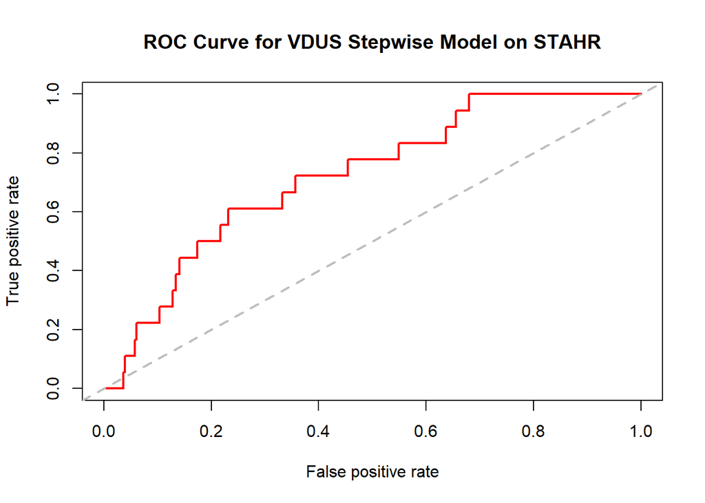

```r
VDUS.STAHR.pr <- predict(VDUS.final.model, df_STAHR, type="response")
VDUS.STAHR.pred <- prediction(VDUS.STAHR.pr, df_STAHR$Past_6Mos_Initiated)
VDUS.STAHR.perf <- performance(VDUS.STAHR.pred,measure = "tpr",x.measure = "fpr")
plot(VDUS.STAHR.perf,main="ROC Curve for VDUS Stepwise Model on STAHR",col=2,lwd=2)
abline(a=0,b=1,lwd=2,lty=2,col="gray")
```

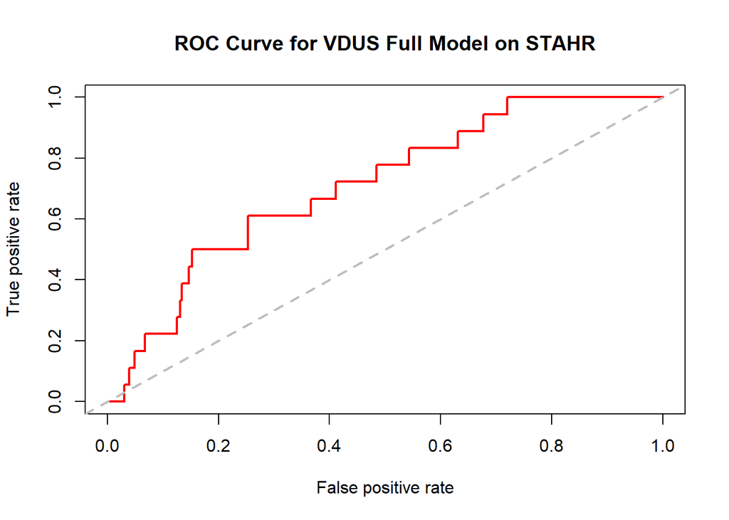

```r
VDUS.STAHR.full.pr <- predict(VDUS.model.full, df_STAHR, type="response")
VDUS.STAHR.full.pred <- prediction(VDUS.STAHR.full.pr, df_STAHR$Past_6Mos_Initiated)
VDUS.STAHR.full.perf <- performance(VDUS.STAHR.full.pred,measure = "tpr",x.measure = "fpr")
plot(VDUS.STAHR.full.perf,main="ROC Curve for VDUS Full Model on STAHR",col=2,lwd=2)
abline(a=0,b=1,lwd=2,lty=2,col="gray")
```

## Three Site MV Model

#### Bivariate Analyses

```r
bi.final <- data.frame(matrix(nrow = 0, ncol = 3))

bi.model <- glm(Past_6Mos_Initiated ~ Initiated_Ever_Prior_To_Past_6Mos, data = df, family = binomial(link = "logit"))
bi.results <- exp(cbind(OR = coef(bi.model), confint(bi.model)))
bi.final <- rbind(bi.final, bi.results)

bi.model <- glm(Past_6Mos_Initiated ~ SITE, data = df, family = binomial(link = "logit"))
bi.results <- exp(cbind(OR = coef(bi.model), confint(bi.model)))
bi.final <- rbind(bi.final, bi.results)

bi.model <- glm(Past_6Mos_Initiated ~ Age, data = df, family = binomial(link = "logit"))
bi.results <- exp(cbind(OR = coef(bi.model), confint(bi.model)))
bi.final <- rbind(bi.final, bi.results)

bi.model <- glm(Past_6Mos_Initiated ~ Years_Since_First_Injection, data = df, family = binomial(link = "logit"))
bi.results <- exp(cbind(OR = coef(bi.model), confint(bi.model)))
bi.final <- rbind(bi.final, bi.results)

bi.model <- glm(Past_6Mos_Initiated ~ Gender, data = df, family = binomial(link = "logit"))
bi.results <- exp(cbind(OR = coef(bi.model), confint(bi.model)))
bi.final <- rbind(bi.final, bi.results)

bi.model <- glm(Past_6Mos_Initiated ~ stable_housing, data = df, family = binomial(link = "logit"))
bi.results <- exp(cbind(OR = coef(bi.model), confint(bi.model)))
bi.final <- rbind(bi.final, bi.results)

bi.model <- glm(Past_6Mos_Initiated ~ Past_6Mos_Heroin_NonInjection_Use, data = df, family = binomial(link = "logit"))
bi.results <- exp(cbind(OR = coef(bi.model), confint(bi.model)))
bi.final <- rbind(bi.final, bi.results)

bi.model <- glm(Past_6Mos_Initiated ~ Past_6Mos_Heroin_Injection_Use, data = df, family = binomial(link = "logit"))
bi.results <- exp(cbind(OR = coef(bi.model), confint(bi.model)))
bi.final <- rbind(bi.final, bi.results)

bi.model <- glm(Past_6Mos_Initiated ~ Past_6Mos_Cocaine_NonInjection_Use, data = df, family = binomial(link = "logit"))
bi.results <- exp(cbind(OR = coef(bi.model), confint(bi.model)))
bi.final <- rbind(bi.final, bi.results)

bi.model <- glm(Past_6Mos_Initiated ~ Past_6Mos_Cocaine_Injection_Use, data = df, family = binomial(link = "logit"))
bi.results <- exp(cbind(OR = coef(bi.model), confint(bi.model)))
bi.final <- rbind(bi.final, bi.results)

bi.model <- glm(Past_6Mos_Initiated ~ Past_6Mos_Meth_NonInjection_Use, data = df, family = binomial(link = "logit"))
bi.results <- exp(cbind(OR = coef(bi.model), confint(bi.model)))
bi.final <- rbind(bi.final, bi.results)

bi.model <- glm(Past_6Mos_Initiated ~ Past_6Mos_Meth_Injection_Use, data = df, family = binomial(link = "logit"))
bi.results <- exp(cbind(OR = coef(bi.model), confint(bi.model)))
bi.final <- rbind(bi.final, bi.results)

bi.model <- glm(Past_6Mos_Initiated ~ Past_6Mos_Injection_Frequency, data = df, family = binomial(link = "logit"))
bi.results <- exp(cbind(OR = coef(bi.model), confint(bi.model)))
bi.final <- rbind(bi.final, bi.results)

bi.model <- glm(Past_6Mos_Initiated ~ Past_6Mos_MAT, data = df, family = binomial(link = "logit"))
bi.results <- exp(cbind(OR = coef(bi.model), confint(bi.model)))
bi.final <- rbind(bi.final, bi.results)



bi.signif <- bi.final[which(bi.final$`2.5 %` > 1 | bi.final$`97.5 %`<1),]

bi.final %>%  kable() %>%
  kable_styling()
```

|  | OR | 2.5 % | 97.5 % |
| --- | --- | --- | --- |
| (Intercept) | 0.0178571 | 0.0122518 | 0.0249887 |
| Initiated_Ever_Prior_To_Past_6MosYes | 7.6674813 | 4.9152106 | 12.1738570 |
| (Intercept)1 | 0.0451866 | 0.0289141 | 0.0669436 |
| SITESTAHR | 1.2144751 | 0.6376724 | 2.2789507 |
| SITEVDUS | 0.7782875 | 0.4720321 | 1.3181983 |
| (Intercept)2 | 0.2247515 | 0.1021551 | 0.4828446 |
| Age | 0.9595998 | 0.9412324 | 0.9778993 |
| (Intercept)3 | 0.0690743 | 0.0460163 | 0.1011331 |
| Years_Since_First_Injection | 0.9738392 | 0.9560805 | 0.9912557 |
| (Intercept)4 | 0.0309973 | 0.0198836 | 0.0457729 |
| GenderMale | 1.4716291 | 0.9200139 | 2.4370297 |
| (Intercept)5 | 0.0731707 | 0.0483477 | 0.1059573 |
| stable_housingYes | 0.4617117 | 0.2922110 | 0.7477081 |
| (Intercept)6 | 0.0392457 | 0.0309949 | 0.0489036 |
| Past_6Mos_Heroin_NonInjection_UseYes | 1.3923781 | 0.6666077 | 2.6135870 |
| (Intercept)7 | 0.0287009 | 0.0204326 | 0.0390135 |
| Past_6Mos_Heroin_Injection_UseYes | 2.0794923 | 1.3522449 | 3.2213858 |
| (Intercept)8 | 0.0375254 | 0.0294962 | 0.0469501 |
| Past_6Mos_Cocaine_NonInjection_UseYes | 2.0024996 | 1.0426747 | 3.5634142 |
| (Intercept)9 | 0.0389269 | 0.0305934 | 0.0487118 |
| Past_6Mos_Cocaine_Injection_UseYes | 1.3686863 | 0.7158582 | 2.4209397 |
| (Intercept)10 | 0.0330469 | 0.0246111 | 0.0432867 |
| Past_6Mos_Meth_NonInjection_UseYes | 1.7715506 | 1.1399558 | 2.7295236 |
| (Intercept)11 | 0.0219780 | 0.0155085 | 0.0300786 |
| Past_6Mos_Meth_Injection_UseYes | 4.5769231 | 2.9636441 | 7.1399947 |
| (Intercept)12 | 0.0727056 | 0.0554952 | 0.0934131 |
| Past_6Mos_Injection_FrequencyLess than daily | 0.5094111 | 0.2933599 | 0.8459269 |
| Past_6Mos_Injection_FrequencyNone | 0.1214107 | 0.0502985 | 0.2492356 |
| (Intercept)13 | 0.0469613 | 0.0364796 | 0.0593773 |
| Past_6Mos_MATYes | 0.5804709 | 0.3371794 | 0.9530618 |

#### Multivariate Log Reg

```r
model.null = glm(Past_6Mos_Initiated ~ 1,
                 data=df,
                 family = binomial(link="logit")
                 )

model.full = glm(Past_6Mos_Initiated ~ SITE + Age + Gender + stable_housing+Years_Since_First_Injection +Past_6Mos_Heroin_NonInjection_Use + Past_6Mos_Heroin_Injection_Use + Past_6Mos_Cocaine_NonInjection_Use + Past_6Mos_Cocaine_Injection_Use + + Past_6Mos_Meth_NonInjection_Use + Past_6Mos_Meth_Injection_Use + Past_6Mos_Injection_Frequency + Past_6Mos_MAT + Initiated_Ever_Prior_To_Past_6Mos,
                 data=df,
                 family = binomial(link="logit")
                 )

step.results <- step(model.null,
     scope = list(upper=model.full),
             direction="both",
             test="Chisq",
             data=df, trace = 0)

final.model <- eval(step.results$call)

results <- round(exp(cbind(OR = coef(final.model), confint(final.model))),2)
print("The Results of the Stepwise Model")
```

```
## [1] "The Results of the Stepwise Model"
```

```r
results %>%  kable() %>%
  kable_styling()
```

|  | OR | 2.5 % | 97.5 % |
| --- | --- | --- | --- |
| (Intercept) | 0.08 | 0.03 | 0.20 |
| Initiated_Ever_Prior_To_Past_6MosYes | 7.11 | 4.48 | 11.48 |
| Past_6Mos_Injection_FrequencyLess than daily | 0.49 | 0.27 | 0.85 |
| Past_6Mos_Injection_FrequencyNone | 0.19 | 0.08 | 0.43 |
| Past_6Mos_Meth_Injection_UseYes | 2.16 | 1.32 | 3.58 |
| Age | 0.97 | 0.95 | 0.99 |
| Past_6Mos_MATYes | 0.60 | 0.34 | 1.02 |
| GenderMale | 1.62 | 0.97 | 2.79 |

```r
full.results <- round(exp(cbind(OR = coef(model.full), confint(model.full))),2)
print("The Results of the Full Model")
```

```
## [1] "The Results of the Full Model"
```

```r
full.results %>%  kable() %>%
  kable_styling()
```

|  | OR | 2.5 % | 97.5 % |
| --- | --- | --- | --- |
| (Intercept) | 0.09 | 0.02 | 0.33 |
| SITESTAHR | 0.70 | 0.30 | 1.60 |
| SITEVDUS | 0.87 | 0.44 | 1.72 |
| Age | 0.97 | 0.93 | 1.00 |
| GenderMale | 1.54 | 0.91 | 2.67 |
| stable_housingYes | 0.78 | 0.46 | 1.35 |
| Years_Since_First_Injection | 1.00 | 0.97 | 1.04 |
| Past_6Mos_Heroin_NonInjection_UseYes | 0.69 | 0.28 | 1.56 |
| Past_6Mos_Heroin_Injection_UseYes | 1.01 | 0.59 | 1.74 |
| Past_6Mos_Cocaine_NonInjection_UseYes | 2.04 | 0.92 | 4.29 |
| Past_6Mos_Cocaine_Injection_UseYes | 0.78 | 0.37 | 1.57 |
| Past_6Mos_Meth_NonInjection_UseYes | 0.87 | 0.50 | 1.47 |
| Past_6Mos_Meth_Injection_UseYes | 2.32 | 1.30 | 4.17 |
| Past_6Mos_Injection_FrequencyLess than daily | 0.52 | 0.28 | 0.94 |
| Past_6Mos_Injection_FrequencyNone | 0.19 | 0.07 | 0.50 |
| Past_6Mos_MATYes | 0.62 | 0.32 | 1.16 |
| Initiated_Ever_Prior_To_Past_6MosYes | 7.63 | 4.72 | 12.54 |